# 11. Splitting data

Often one has tables that mix regular variables (e.g. the size of cells in microscopy images) with categorical variables (e.g. the type of cell to which they belong). In that case, it is quite usual to split the data by categories or *groups* to do computations. Pandas allows to do this very easily.

```python
import numpy as np
import pandas as pd
import matplotlib.pyplot as plt
```

## 11.1 Grouping

Let's import some data and have a look at them:

```python
composers = pd.read_excel('Data/composers.xlsx', sheet_name='Sheet5')
```

```python
composers.head()
```

|  | composer | birth | death | period | country |
| --- | --- | --- | --- | --- | --- |
| 0 | Mahler | 1860 | 1911.0 | post-romantic | Austria |
| 1 | Beethoven | 1770 | 1827.0 | romantic | Germany |
| 2 | Puccini | 1858 | 1924.0 | post-romantic | Italy |
| 3 | Shostakovich | 1906 | 1975.0 | modern | Russia |
| 4 | Verdi | 1813 | 1901.0 | romantic | Italy |

We also add a column here to calculate the composers' age:

```python
composers['age'] = composers.death - composers.birth
```

### 11.1.1 Single level

What if we want now to count how many composers we have in a certain category like the period or country? In classical computing we would maybe do a for loop to count occurrences. Pandas simplifies this with the `groupby()` function, which actually groups elements by a certain criteria, e.g. a categorical variable like the period:

```python
composer_grouped = composers.groupby('period')
composer_grouped
```

```
<pandas.core.groupby.generic.DataFrameGroupBy object at 0x11d2fc850>
```

The output is a bit cryptic. What we actually have is a new object called a group which has a lot of handy properties. First let's see what the groups actually are. We can find all groups with `groups`:

```python
composer_grouped.groups
```

```
{'baroque': Int64Index([14, 16, 17, 20, 21, 28, 29, 30, 31, 47], dtype='int64'),
 'classic': Int64Index([9, 10, 32, 40, 51], dtype='int64'),
 'modern': Int64Index([3, 7, 11, 12, 19, 25, 45, 46, 50, 53, 54, 55, 56], dtype='int64'),
 'post-romantic': Int64Index([0, 2, 8, 18, 49], dtype='int64'),
 'renaissance': Int64Index([13, 26, 27, 36, 37, 43, 44], dtype='int64'),
 'romantic': Int64Index([1, 4, 5, 6, 15, 22, 23, 24, 33, 34, 35, 38, 39, 41, 42, 48, 52], dtype='int64')}
```

We have a dictionary, where each *period* that appears in the Dataframe is a key and each key contains a list of dataframe *indices* of rows with those periods. We will rarely directly use those indices, as most operations on groups only use those "behind the scene".

For example we can use `describe()` on a group object, just like we did it before for a Dataframe:

```python
composer_grouped.describe()#.loc['Austria','birth']
```

| period | birth count | birth mean | birth std | birth min | birth 25% | birth 50% | birth 75% | birth max | death count | death mean | death ... | death 75% | death max | age count | age mean | age std | age min | age 25% | age 50% | age 75% | age max |
| --- | --- | --- | --- | --- | --- | --- | --- | --- | --- | --- | --- | --- | --- | --- | --- | --- | --- | --- | --- | --- | --- |
| baroque | 10.0 | 1663.300000 | 36.009412 | 1587.0 | 1647.0 | 1676.5 | 1685.0 | 1710.0 | 10.0 | 1720.200000 | ... | 1755.25 | 1764.0 | 10.0 | 56.900000 | 18.716897 | 26.0 | 40.25 | 63.0 | 70.5 | 81.0 |
| classic | 5.0 | 1744.400000 | 12.054045 | 1731.0 | 1732.0 | 1749.0 | 1754.0 | 1756.0 | 5.0 | 1801.200000 | ... | 1806.00 | 1809.0 | 5.0 | 56.800000 | 16.238842 | 35.0 | 52.00 | 52.0 | 68.0 | 77.0 |
| modern | 13.0 | 1905.692308 | 28.595992 | 1854.0 | 1891.0 | 1902.0 | 1918.0 | 1971.0 | 11.0 | 1974.090909 | ... | 1990.00 | 2016.0 | 11.0 | 77.181818 | 13.136348 | 50.0 | 70.50 | 81.0 | 88.0 | 91.0 |
| post-romantic | 5.0 | 1854.200000 | 17.123084 | 1824.0 | 1858.0 | 1860.0 | 1864.0 | 1865.0 | 5.0 | 1927.400000 | ... | 1949.00 | 1957.0 | 5.0 | 73.200000 | 16.115210 | 51.0 | 66.00 | 72.0 | 85.0 | 92.0 |
| renaissance | 7.0 | 1527.142857 | 59.881629 | 1397.0 | 1528.5 | 1540.0 | 1564.5 | 1567.0 | 7.0 | 1595.285714 | ... | 1624.50 | 1643.0 | 7.0 | 68.142857 | 12.061351 | 47.0 | 62.50 | 69.0 | 76.5 | 83.0 |
| romantic | 17.0 | 1824.823529 | 25.468695 | 1770.0 | 1810.0 | 1824.0 | 1841.0 | 1867.0 | 17.0 | 1883.588235 | ... | 1904.00 | 1919.0 | 17.0 | 58.764706 | 13.250139 | 34.0 | 49.00 | 60.0 | 66.0 | 88.0 |

6 rows × 24 columns

We see here that the statistical analysis has been done for each group, the index of each row being the group name (or key in the dictionary). If we are interested in a specific group we can also easily recover it:

```python
composer_grouped.get_group('classic')
```

|  | composer | birth | death | period | country | age |
| --- | --- | --- | --- | --- | --- | --- |
| 9 | Haydn | 1732 | 1809.0 | classic | Austria | 77.0 |
| 10 | Mozart | 1756 | 1791.0 | classic | Austria | 35.0 |
| 32 | Cimarosa | 1749 | 1801.0 | classic | Italy | 52.0 |
| 40 | Soler | 1754 | 1806.0 | classic | Spain | 52.0 |
| 51 | Dusek | 1731 | 1799.0 | classic | Czechia | 68.0 |

We see that this returns a sub-group from the original table. Effectively it is almost equivalent to:

```python
composers[composers.period == 'classic']
```

|  | composer | birth | death | period | country | age |
| --- | --- | --- | --- | --- | --- | --- |
| 9 | Haydn | 1732 | 1809.0 | classic | Austria | 77.0 |
| 10 | Mozart | 1756 | 1791.0 | classic | Austria | 35.0 |
| 32 | Cimarosa | 1749 | 1801.0 | classic | Italy | 52.0 |
| 40 | Soler | 1754 | 1806.0 | classic | Spain | 52.0 |
| 51 | Dusek | 1731 | 1799.0 | classic | Czechia | 68.0 |

### 11.1.2 Multi-level

If one has multiple categorical variables, one can also do a grouping on several levels. For example here we want to classify composers both by period and country. For this we just give two column names to the `groupby()` function:

```python
composer_grouped = composers.groupby(['period','country'])
composer_grouped.describe()
```

| period | country | birth count | birth mean | birth std | birth min | birth 25% | birth 50% | birth 75% | birth max | death count | death mean | death ... | death 75% | death max | age count | age mean | age std | age min | age 25% | age 50% | age 75% | age max |
| --- | --- | --- | --- | --- | --- | --- | --- | --- | --- | --- | --- | --- | --- | --- | --- | --- | --- | --- | --- | --- | --- | --- |
| baroque | England | 1.0 | 1659.000000 | NaN | 1659.0 | 1659.00 | 1659.0 | 1659.00 | 1659.0 | 1.0 | 1695.000000 | ... | 1695.00 | 1695.0 | 1.0 | 36.000000 | NaN | 36.0 | 36.00 | 36.0 | 36.00 | 36.0 |
|  | France | 3.0 | 1650.666667 | 29.263174 | 1626.0 | 1634.50 | 1643.0 | 1663.00 | 1683.0 | 3.0 | 1709.666667 | ... | 1734.00 | 1764.0 | 3.0 | 59.000000 | 23.065125 | 35.0 | 48.00 | 61.0 | 71.00 | 81.0 |
|  | Germany | 2.0 | 1685.000000 | 0.000000 | 1685.0 | 1685.00 | 1685.0 | 1685.00 | 1685.0 | 2.0 | 1754.500000 | ... | 1756.75 | 1759.0 | 2.0 | 69.500000 | 6.363961 | 65.0 | 67.25 | 69.5 | 71.75 | 74.0 |
|  | Italy | 4.0 | 1663.000000 | 53.285395 | 1587.0 | 1649.25 | 1677.5 | 1691.25 | 1710.0 | 4.0 | 1717.250000 | ... | 1741.25 | 1757.0 | 4.0 | 54.250000 | 20.434856 | 26.0 | 46.25 | 59.5 | 67.50 | 72.0 |
| classic | Austria | 2.0 | 1744.000000 | 16.970563 | 1732.0 | 1738.00 | 1744.0 | 1750.00 | 1756.0 | 2.0 | 1800.000000 | ... | 1804.50 | 1809.0 | 2.0 | 56.000000 | 29.698485 | 35.0 | 45.50 | 56.0 | 66.50 | 77.0 |
|  | Czechia | 1.0 | 1731.000000 | NaN | 1731.0 | 1731.00 | 1731.0 | 1731.00 | 1731.0 | 1.0 | 1799.000000 | ... | 1799.00 | 1799.0 | 1.0 | 68.000000 | NaN | 68.0 | 68.00 | 68.0 | 68.00 | 68.0 |
|  | Italy | 1.0 | 1749.000000 | NaN | 1749.0 | 1749.00 | 1749.0 | 1749.00 | 1749.0 | 1.0 | 1801.000000 | ... | 1801.00 | 1801.0 | 1.0 | 52.000000 | NaN | 52.0 | 52.00 | 52.0 | 52.00 | 52.0 |
|  | Spain | 1.0 | 1754.000000 | NaN | 1754.0 | 1754.00 | 1754.0 | 1754.00 | 1754.0 | 1.0 | 1806.000000 | ... | 1806.00 | 1806.0 | 1.0 | 52.000000 | NaN | 52.0 | 52.00 | 52.0 | 52.00 | 52.0 |
| modern | Austria | 1.0 | 1885.000000 | NaN | 1885.0 | 1885.00 | 1885.0 | 1885.00 | 1885.0 | 1.0 | 1935.000000 | ... | 1935.00 | 1935.0 | 1.0 | 50.000000 | NaN | 50.0 | 50.00 | 50.0 | 50.00 | 50.0 |
|  | Czechia | 1.0 | 1854.000000 | NaN | 1854.0 | 1854.00 | 1854.0 | 1854.00 | 1854.0 | 1.0 | 1928.000000 | ... | 1928.00 | 1928.0 | 1.0 | 74.000000 | NaN | 74.0 | 74.00 | 74.0 | 74.00 | 74.0 |
|  | England | 2.0 | 1936.500000 | 48.790368 | 1902.0 | 1919.25 | 1936.5 | 1953.75 | 1971.0 | 1.0 | 1983.000000 | ... | 1983.00 | 1983.0 | 1.0 | 81.000000 | NaN | 81.0 | 81.00 | 81.0 | 81.00 | 81.0 |
|  | France | 2.0 | 1916.500000 | 12.020815 | 1908.0 | 1912.25 | 1916.5 | 1920.75 | 1925.0 | 2.0 | 2004.000000 | ... | 2010.00 | 2016.0 | 2.0 | 87.500000 | 4.949747 | 84.0 | 85.75 | 87.5 | 89.25 | 91.0 |
|  | Germany | 1.0 | 1895.000000 | NaN | 1895.0 | 1895.00 | 1895.0 | 1895.00 | 1895.0 | 1.0 | 1982.000000 | ... | 1982.00 | 1982.0 | 1.0 | 87.000000 | NaN | 87.0 | 87.00 | 87.0 | 87.00 | 87.0 |
|  | RUssia | 1.0 | 1891.000000 | NaN | 1891.0 | 1891.00 | 1891.0 | 1891.00 | 1891.0 | 1.0 | 1953.000000 | ... | 1953.00 | 1953.0 | 1.0 | 62.000000 | NaN | 62.0 | 62.00 | 62.0 | 62.00 | 62.0 |
|  | Russia | 2.0 | 1894.000000 | 16.970563 | 1882.0 | 1888.00 | 1894.0 | 1900.00 | 1906.0 | 2.0 | 1973.000000 | ... | 1974.00 | 1975.0 | 2.0 | 79.000000 | 14.142136 | 69.0 | 74.00 | 79.0 | 84.00 | 89.0 |
|  | USA | 3.0 | 1918.333333 | 18.502252 | 1900.0 | 1909.00 | 1918.0 | 1927.50 | 1937.0 | 2.0 | 1990.000000 | ... | 1990.00 | 1990.0 | 2.0 | 81.000000 | 12.727922 | 72.0 | 76.50 | 81.0 | 85.50 | 90.0 |
| post-romantic | Austria | 2.0 | 1842.000000 | 25.455844 | 1824.0 | 1833.00 | 1842.0 | 1851.00 | 1860.0 | 2.0 | 1903.500000 | ... | 1907.25 | 1911.0 | 2.0 | 61.500000 | 14.849242 | 51.0 | 56.25 | 61.5 | 66.75 | 72.0 |
|  | Finland | 1.0 | 1865.000000 | NaN | 1865.0 | 1865.00 | 1865.0 | 1865.00 | 1865.0 | 1.0 | 1957.000000 | ... | 1957.00 | 1957.0 | 1.0 | 92.000000 | NaN | 92.0 | 92.00 | 92.0 | 92.00 | 92.0 |
|  | Germany | 1.0 | 1864.000000 | NaN | 1864.0 | 1864.00 | 1864.0 | 1864.00 | 1864.0 | 1.0 | 1949.000000 | ... | 1949.00 | 1949.0 | 1.0 | 85.000000 | NaN | 85.0 | 85.00 | 85.0 | 85.00 | 85.0 |
|  | Italy | 1.0 | 1858.000000 | NaN | 1858.0 | 1858.00 | 1858.0 | 1858.00 | 1858.0 | 1.0 | 1924.000000 | ... | 1924.00 | 1924.0 | 1.0 | 66.000000 | NaN | 66.0 | 66.00 | 66.0 | 66.00 | 66.0 |
| renaissance | Belgium | 2.0 | 1464.500000 | 95.459415 | 1397.0 | 1430.75 | 1464.5 | 1498.25 | 1532.0 | 2.0 | 1534.000000 | ... | 1564.00 | 1594.0 | 2.0 | 69.500000 | 10.606602 | 62.0 | 65.75 | 69.5 | 73.25 | 77.0 |
|  | England | 2.0 | 1551.500000 | 16.263456 | 1540.0 | 1545.75 | 1551.5 | 1557.25 | 1563.0 | 2.0 | 1624.500000 | ... | 1625.25 | 1626.0 | 2.0 | 73.000000 | 14.142136 | 63.0 | 68.00 | 73.0 | 78.00 | 83.0 |
|  | Italy | 3.0 | 1552.666667 | 23.965253 | 1525.0 | 1545.50 | 1566.0 | 1566.50 | 1567.0 | 3.0 | 1616.666667 | ... | 1628.00 | 1643.0 | 3.0 | 64.000000 | 15.132746 | 47.0 | 58.00 | 69.0 | 72.50 | 76.0 |
| romantic | Czechia | 2.0 | 1832.500000 | 12.020815 | 1824.0 | 1828.25 | 1832.5 | 1836.75 | 1841.0 | 2.0 | 1894.000000 | ... | 1899.00 | 1904.0 | 2.0 | 61.500000 | 2.121320 | 60.0 | 60.75 | 61.5 | 62.25 | 63.0 |
|  | France | 3.0 | 1821.000000 | 19.672316 | 1803.0 | 1810.50 | 1818.0 | 1830.00 | 1842.0 | 3.0 | 1891.333333 | ... | 1902.50 | 1912.0 | 3.0 | 70.333333 | 4.509250 | 66.0 | 68.00 | 70.0 | 72.50 | 75.0 |
|  | Germany | 4.0 | 1806.500000 | 26.388129 | 1770.0 | 1800.00 | 1811.5 | 1818.00 | 1833.0 | 4.0 | 1865.750000 | ... | 1886.50 | 1897.0 | 4.0 | 59.250000 | 10.307764 | 46.0 | 54.25 | 60.5 | 65.50 | 70.0 |
|  | Italy | 4.0 | 1817.250000 | 28.004464 | 1797.0 | 1800.00 | 1807.0 | 1824.25 | 1858.0 | 4.0 | 1875.750000 | ... | 1905.50 | 1919.0 | 4.0 | 58.500000 | 22.605309 | 34.0 | 46.75 | 56.0 | 67.75 | 88.0 |
|  | Russia | 2.0 | 1836.000000 | 4.242641 | 1833.0 | 1834.50 | 1836.0 | 1837.50 | 1839.0 | 2.0 | 1884.000000 | ... | 1885.50 | 1887.0 | 2.0 | 48.000000 | 8.485281 | 42.0 | 45.00 | 48.0 | 51.00 | 54.0 |
|  | Spain | 2.0 | 1863.500000 | 4.949747 | 1860.0 | 1861.75 | 1863.5 | 1865.25 | 1867.0 | 2.0 | 1912.500000 | ... | 1914.25 | 1916.0 | 2.0 | 49.000000 | 0.000000 | 49.0 | 49.00 | 49.0 | 49.00 | 49.0 |

29 rows × 24 columns

```python
composer_grouped.get_group(('baroque','Germany'))
```

|  | composer | birth | death | period | country | age |
| --- | --- | --- | --- | --- | --- | --- |
| 14 | Haendel | 1685 | 1759.0 | baroque | Germany | 74.0 |
| 47 | Bach | 1685 | 1750.0 | baroque | Germany | 65.0 |

## 11.2 Operations on groups

The main advantage of this Group object is that it allows us to do very quickly both computations and plotting without having to loop through different categories. Indeed Pandas makes all the work for us: it applies functions on each group and then reassembles the results into a Dataframe (or Series depending on the operation).

For example we can apply most functions we used for Dataframes (mean, sum etc.) on groups as well and Pandas seamlessly does the work for us:

```python
composer_grouped.mean()
```

| period | country | birth | death | age |
| --- | --- | --- | --- | --- |
| baroque | England | 1659.000000 | 1695.000000 | 36.000000 |
|  | France | 1650.666667 | 1709.666667 | 59.000000 |
|  | Germany | 1685.000000 | 1754.500000 | 69.500000 |
|  | Italy | 1663.000000 | 1717.250000 | 54.250000 |
| classic | Austria | 1744.000000 | 1800.000000 | 56.000000 |
|  | Czechia | 1731.000000 | 1799.000000 | 68.000000 |
|  | Italy | 1749.000000 | 1801.000000 | 52.000000 |
|  | Spain | 1754.000000 | 1806.000000 | 52.000000 |
| modern | Austria | 1885.000000 | 1935.000000 | 50.000000 |
|  | Czechia | 1854.000000 | 1928.000000 | 74.000000 |
|  | England | 1936.500000 | 1983.000000 | 81.000000 |
|  | France | 1916.500000 | 2004.000000 | 87.500000 |
|  | Germany | 1895.000000 | 1982.000000 | 87.000000 |
|  | RUssia | 1891.000000 | 1953.000000 | 62.000000 |
|  | Russia | 1894.000000 | 1973.000000 | 79.000000 |
|  | USA | 1918.333333 | 1990.000000 | 81.000000 |
| post-romantic | Austria | 1842.000000 | 1903.500000 | 61.500000 |
|  | Finland | 1865.000000 | 1957.000000 | 92.000000 |
|  | Germany | 1864.000000 | 1949.000000 | 85.000000 |
|  | Italy | 1858.000000 | 1924.000000 | 66.000000 |
| renaissance | Belgium | 1464.500000 | 1534.000000 | 69.500000 |
|  | England | 1551.500000 | 1624.500000 | 73.000000 |
|  | Italy | 1552.666667 | 1616.666667 | 64.000000 |
| romantic | Czechia | 1832.500000 | 1894.000000 | 61.500000 |
|  | France | 1821.000000 | 1891.333333 | 70.333333 |
|  | Germany | 1806.500000 | 1865.750000 | 59.250000 |
|  | Italy | 1817.250000 | 1875.750000 | 58.500000 |
|  | Russia | 1836.000000 | 1884.000000 | 48.000000 |
|  | Spain | 1863.500000 | 1912.500000 | 49.000000 |

```python
composer_grouped.count()
```

| period | country | composer | birth | death | age |
| --- | --- | --- | --- | --- | --- |
| baroque | England | 1 | 1 | 1 | 1 |
|  | France | 3 | 3 | 3 | 3 |
|  | Germany | 2 | 2 | 2 | 2 |
|  | Italy | 4 | 4 | 4 | 4 |
| classic | Austria | 2 | 2 | 2 | 2 |
|  | Czechia | 1 | 1 | 1 | 1 |
|  | Italy | 1 | 1 | 1 | 1 |
|  | Spain | 1 | 1 | 1 | 1 |
| modern | Austria | 1 | 1 | 1 | 1 |
|  | Czechia | 1 | 1 | 1 | 1 |
|  | England | 2 | 2 | 1 | 1 |
|  | France | 2 | 2 | 2 | 2 |
|  | Germany | 1 | 1 | 1 | 1 |
|  | RUssia | 1 | 1 | 1 | 1 |
|  | Russia | 2 | 2 | 2 | 2 |
|  | USA | 3 | 3 | 2 | 2 |
| post-romantic | Austria | 2 | 2 | 2 | 2 |
|  | Finland | 1 | 1 | 1 | 1 |
|  | Germany | 1 | 1 | 1 | 1 |
|  | Italy | 1 | 1 | 1 | 1 |
| renaissance | Belgium | 2 | 2 | 2 | 2 |
|  | England | 2 | 2 | 2 | 2 |
|  | Italy | 3 | 3 | 3 | 3 |
| romantic | Czechia | 2 | 2 | 2 | 2 |
|  | France | 3 | 3 | 3 | 3 |
|  | Germany | 4 | 4 | 4 | 4 |
|  | Italy | 4 | 4 | 4 | 4 |
|  | Russia | 2 | 2 | 2 | 2 |
|  | Spain | 2 | 2 | 2 | 2 |

We can also design specific functions (again, like in the case of Dataframes) and apply them on groups:

```python
def mult(myseries):
    return myseries.max() * 3
```

```python
composer_grouped.apply(mult)
```

| period | country | composer | birth | death | period | country | age |
| --- | --- | --- | --- | --- | --- | --- | --- |
| baroque | England | PurcellPurcellPurcell | 4977 | 5085.0 | baroquebaroquebaroque | EnglandEnglandEngland | 108.0 |
|  | France | RameauRameauRameau | 5049 | 5292.0 | baroquebaroquebaroque | FranceFranceFrance | 243.0 |
|  | Germany | HaendelHaendelHaendel | 5055 | 5277.0 | baroquebaroquebaroque | GermanyGermanyGermany | 222.0 |
|  | Italy | ScarlattiScarlattiScarlatti | 5130 | 5271.0 | baroquebaroquebaroque | ItalyItalyItaly | 216.0 |
| classic | Austria | MozartMozartMozart | 5268 | 5427.0 | classicclassicclassic | AustriaAustriaAustria | 231.0 |
|  | Czechia | DusekDusekDusek | 5193 | 5397.0 | classicclassicclassic | CzechiaCzechiaCzechia | 204.0 |
|  | Italy | CimarosaCimarosaCimarosa | 5247 | 5403.0 | classicclassicclassic | ItalyItalyItaly | 156.0 |
|  | Spain | SolerSolerSoler | 5262 | 5418.0 | classicclassicclassic | SpainSpainSpain | 156.0 |
| modern | Austria | BergBergBerg | 5655 | 5805.0 | modernmodernmodern | AustriaAustriaAustria | 150.0 |
|  | Czechia | JanacekJanacekJanacek | 5562 | 5784.0 | modernmodernmodern | CzechiaCzechiaCzechia | 222.0 |
|  | England | WaltonWaltonWalton | 5913 | 5949.0 | modernmodernmodern | EnglandEnglandEngland | 243.0 |
|  | France | MessiaenMessiaenMessiaen | 5775 | 6048.0 | modernmodernmodern | FranceFranceFrance | 273.0 |
|  | Germany | OrffOrffOrff | 5685 | 5946.0 | modernmodernmodern | GermanyGermanyGermany | 261.0 |
|  | RUssia | ProkofievProkofievProkofiev | 5673 | 5859.0 | modernmodernmodern | RUssiaRUssiaRUssia | 186.0 |
|  | Russia | StravinskyStravinskyStravinsky | 5718 | 5925.0 | modernmodernmodern | RussiaRussiaRussia | 267.0 |
|  | USA | GlassGlassGlass | 5811 | 5970.0 | modernmodernmodern | USAUSAUSA | 270.0 |
| post-romantic | Austria | MahlerMahlerMahler | 5580 | 5733.0 | post-romanticpost-romanticpost-romantic | AustriaAustriaAustria | 216.0 |
|  | Finland | SibeliusSibeliusSibelius | 5595 | 5871.0 | post-romanticpost-romanticpost-romantic | FinlandFinlandFinland | 276.0 |
|  | Germany | StraussStraussStrauss | 5592 | 5847.0 | post-romanticpost-romanticpost-romantic | GermanyGermanyGermany | 255.0 |
|  | Italy | PucciniPucciniPuccini | 5574 | 5772.0 | post-romanticpost-romanticpost-romantic | ItalyItalyItaly | 198.0 |
| renaissance | Belgium | LassusLassusLassus | 4596 | 4782.0 | renaissancerenaissancerenaissance | BelgiumBelgiumBelgium | 231.0 |
|  | England | DowlandDowlandDowland | 4689 | 4878.0 | renaissancerenaissancerenaissance | EnglandEnglandEngland | 249.0 |
|  | Italy | PalestrinaPalestrinaPalestrina | 4701 | 4929.0 | renaissancerenaissancerenaissance | ItalyItalyItaly | 228.0 |
| romantic | Czechia | SmetanaSmetanaSmetana | 5523 | 5712.0 | romanticromanticromantic | CzechiaCzechiaCzechia | 189.0 |
|  | France | MassenetMassenetMassenet | 5526 | 5736.0 | romanticromanticromantic | FranceFranceFrance | 225.0 |
|  | Germany | WagnerWagnerWagner | 5499 | 5691.0 | romanticromanticromantic | GermanyGermanyGermany | 210.0 |
|  | Italy | VerdiVerdiVerdi | 5574 | 5757.0 | romanticromanticromantic | ItalyItalyItaly | 264.0 |
|  | Russia | MussorsgskyMussorsgskyMussorsgsky | 5517 | 5661.0 | romanticromanticromantic | RussiaRussiaRussia | 162.0 |
|  | Spain | GranadosGranadosGranados | 5601 | 5748.0 | romanticromanticromantic | SpainSpainSpain | 147.0 |

## 11.3 Reshaping dataframes

As we see above, grouping operations can create more or less complex dataframes by adding one or multiple indexing levels. There are multiple ways to "reshape" such dataframes in order to make thm usable e.g. for plotting. Typically, plotting software based on a grammar of graphics expect a simple 2D dataframe where each line is an observation with several properties.

### 11.3.1 re-indexing, unstacking

One of the most common "reshaping" is to reset the index. In its simplest form, it will create a new dataframe, where each row corresponds to one observation. For example in the case of a dataframe with multi-indices, it will re-cast these indices as columns:

```python
composer_grouped = composers.groupby(['period','country']).mean()
composer_grouped.head(10)
```

| period | country | birth | death | age |
| --- | --- | --- | --- | --- |
| baroque | England | 1659.000000 | 1695.000000 | 36.00 |
|  | France | 1650.666667 | 1709.666667 | 59.00 |
|  | Germany | 1685.000000 | 1754.500000 | 69.50 |
|  | Italy | 1663.000000 | 1717.250000 | 54.25 |
| classic | Austria | 1744.000000 | 1800.000000 | 56.00 |
|  | Czechia | 1731.000000 | 1799.000000 | 68.00 |
|  | Italy | 1749.000000 | 1801.000000 | 52.00 |
|  | Spain | 1754.000000 | 1806.000000 | 52.00 |
| modern | Austria | 1885.000000 | 1935.000000 | 50.00 |
|  | Czechia | 1854.000000 | 1928.000000 | 74.00 |

```python
composer_grouped.reset_index().head(5)
```

|  | period | country | birth | death | age |
| --- | --- | --- | --- | --- | --- |
| 0 | baroque | England | 1659.000000 | 1695.000000 | 36.00 |
| 1 | baroque | France | 1650.666667 | 1709.666667 | 59.00 |
| 2 | baroque | Germany | 1685.000000 | 1754.500000 | 69.50 |
| 3 | baroque | Italy | 1663.000000 | 1717.250000 | 54.25 |
| 4 | classic | Austria | 1744.000000 | 1800.000000 | 56.00 |

One can of course be more specific and reset only specific indices e.g. by level:

```python
composer_grouped.reset_index(level=1).head(5)
```

| period | country | birth | death | age |
| --- | --- | --- | --- | --- |
| baroque | England | 1659.000000 | 1695.000000 | 36.00 |
| baroque | France | 1650.666667 | 1709.666667 | 59.00 |
| baroque | Germany | 1685.000000 | 1754.500000 | 69.50 |
| baroque | Italy | 1663.000000 | 1717.250000 | 54.25 |
| classic | Austria | 1744.000000 | 1800.000000 | 56.00 |

### 11.3.2 unstacking

Another way to move indices to columns is to *unstack* a dataframe, in other words pivot some indices to columns:

```python
composer_grouped.unstack()
```

| country period | birth Austria | birth Belgium | birth Czechia | birth England | birth Finland | birth France | birth Germany | birth Italy | birth RUssia | birth Russia | ... | age Czechia | age England | age Finland | age France | age Germany | age Italy | age RUssia | age Russia | age Spain | age USA |
| --- | --- | --- | --- | --- | --- | --- | --- | --- | --- | --- | --- | --- | --- | --- | --- | --- | --- | --- | --- | --- | --- |
| baroque | NaN | NaN | NaN | 1659.0 | NaN | 1650.666667 | 1685.0 | 1663.000000 | NaN | NaN | ... | NaN | 36.0 | NaN | 59.000000 | 69.50 | 54.25 | NaN | NaN | NaN | NaN |
| classic | 1744.0 | NaN | 1731.0 | NaN | NaN | NaN | NaN | 1749.000000 | NaN | NaN | ... | 68.0 | NaN | NaN | NaN | NaN | 52.00 | NaN | NaN | 52.0 | NaN |
| modern | 1885.0 | NaN | 1854.0 | 1936.5 | NaN | 1916.500000 | 1895.0 | NaN | 1891.0 | 1894.0 | ... | 74.0 | 81.0 | NaN | 87.500000 | 87.00 | NaN | 62.0 | 79.0 | NaN | 81.0 |
| post-romantic | 1842.0 | NaN | NaN | NaN | 1865.0 | NaN | 1864.0 | 1858.000000 | NaN | NaN | ... | NaN | NaN | 92.0 | NaN | 85.00 | 66.00 | NaN | NaN | NaN | NaN |
| renaissance | NaN | 1464.5 | NaN | 1551.5 | NaN | NaN | NaN | 1552.666667 | NaN | NaN | ... | NaN | 73.0 | NaN | NaN | NaN | 64.00 | NaN | NaN | NaN | NaN |
| romantic | NaN | NaN | 1832.5 | NaN | NaN | 1821.000000 | 1806.5 | 1817.250000 | NaN | 1836.0 | ... | 61.5 | NaN | NaN | 70.333333 | 59.25 | 58.50 | NaN | 48.0 | 49.0 | NaN |

6 rows × 36 columns

This creates a multi-level column indexing.

### 11.3.3 Wide to long: melt

A very common operation when handling tables is to switch from wide to long format and vice versa. In our composer example, let's for example imagine that you want both `birth` and `death` dates to be grouped in a single column called `dates`. But you still need to know if that data is a birth or date, so you need a new column that indicates that. To achieve that, we need to specify `id_vars` a list of columns to be used as *identifiers* e.g. the composer name, and `value_vars`, a list of columns that should become rows:

```python
composers.head(5)
```

|  | composer | birth | death | period | country | age |
| --- | --- | --- | --- | --- | --- | --- |
| 0 | Mahler | 1860 | 1911.0 | post-romantic | Austria | 51.0 |
| 1 | Beethoven | 1770 | 1827.0 | romantic | Germany | 57.0 |
| 2 | Puccini | 1858 | 1924.0 | post-romantic | Italy | 66.0 |
| 3 | Shostakovich | 1906 | 1975.0 | modern | Russia | 69.0 |
| 4 | Verdi | 1813 | 1901.0 | romantic | Italy | 88.0 |

```python
pd.melt(composers, id_vars=['composer'], value_vars=['birth', 'death'])
```

|  | composer | variable | value |
| --- | --- | --- | --- |
| 0 | Mahler | birth | 1860.0 |
| 1 | Beethoven | birth | 1770.0 |
| 2 | Puccini | birth | 1858.0 |
| 3 | Shostakovich | birth | 1906.0 |
| 4 | Verdi | birth | 1813.0 |
| ... | ... | ... | ... |
| 109 | Smetana | death | 1884.0 |
| 110 | Janacek | death | 1928.0 |
| 111 | Copland | death | 1990.0 |
| 112 | Bernstein | death | 1990.0 |
| 113 | Glass | death | NaN |

114 rows × 3 columns

We can keep more of the original columns as *identifiers* and also specify names for the *variable* and *value* columns:

```python
melted = pd.melt(composers, id_vars=['composer','period','age','country'], value_vars=['birth', 'death'],
                var_name = 'date_type', value_name='dates')
melted
```

|  | composer | period | age | country | date_type | dates |
| --- | --- | --- | --- | --- | --- | --- |
| 0 | Mahler | post-romantic | 51.0 | Austria | birth | 1860.0 |
| 1 | Beethoven | romantic | 57.0 | Germany | birth | 1770.0 |
| 2 | Puccini | post-romantic | 66.0 | Italy | birth | 1858.0 |
| 3 | Shostakovich | modern | 69.0 | Russia | birth | 1906.0 |
| 4 | Verdi | romantic | 88.0 | Italy | birth | 1813.0 |
| ... | ... | ... | ... | ... | ... | ... |
| 109 | Smetana | romantic | 60.0 | Czechia | death | 1884.0 |
| 110 | Janacek | modern | 74.0 | Czechia | death | 1928.0 |
| 111 | Copland | modern | 90.0 | USA | death | 1990.0 |
| 112 | Bernstein | modern | 72.0 | USA | death | 1990.0 |
| 113 | Glass | modern | NaN | USA | death | NaN |

114 rows × 6 columns

## 11.4 Plotting

We have seen above that we can create groups and apply functions to them to get some summary of them as new dataframes or series that could then also be reshaped. The final result of these operations is then ideally suited to be plotted in a very efficient way.

Here's a simple example: we group composers by periods and then calculate the mean age, resulting in a series where periods are indices:

```python
composers.groupby('period')['age'].mean()
```

```
period
baroque          56.900000
classic          56.800000
modern           77.181818
post-romantic    73.200000
renaissance      68.142857
romantic         58.764706
Name: age, dtype: float64
```

We can just add one more operation to that line to create a bar plot illustrating this:

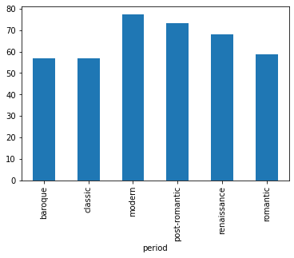

```python
composers.groupby('period')['age'].mean().plot(kind = 'bar');
```

Using more advanced libraries, we can go further than that and use multiple columns to create complex plots. This will be shown in the next chapter.